# Assignment #4

Vishesh Kakarala

April 11, 2016

```r
library('stats')
library('networkD3')
library('igraph')
library('twitteR')
library('RCurl')
library('ngram')
library('js')
library('tau')
library('tm')
library('stringdist')
```

# Question 1. Intro Network Analyses

a)Read in the files and visualize the network. Read the data

```r
keys <- read.table("~/Assignment 4/keys.txt", sep = "\t", fill = FALSE, col.names = c("node_id","name"))
Subs <- read.table("~/Assignment 4/subs.txt", sep = "\t", fill = FALSE, col.names = c("ingredient_A","ingredient_B"))
```

Visualizing the network using forceNetwork function form networkD3 library

```r
keys$group <- 1

keys$node_id <- keys$node_id-1
Subs$ingredient_A <- Subs$ingredient_A-1
Subs$ingredient_B <- Subs$ingredient_B-1
forceNetwork(Links = Subs,Nodes = keys,Source = "ingredient_A", Target = "ingredient_B",NodeID = "name",Group = "group",zoom = TRUE, opacityNoHover = T)
```

[interactive chart not shown]

b)Calculate the degree centrality of each node

```r
deg <- graph.data.frame(Subs,keys, directed = T)
keys$centrality <- degree(deg,mode = "Total")
keys$standardized_centrality <- keys$centrality/561

head(keys)
```

```
##   node_id        name group centrality standardized_centrality
## 1       0        leek     1          3             0.005347594
## 2       1       onion     1         33             0.058823529
## 3       2 white onion     1          4             0.007130125
## 4       3     shallot     1          8             0.014260250
## 5       4     hot dog     1          1             0.001782531
## 6       5     sausage     1         19             0.033868093
```

d)Which are the most “connected” node(s). To see which of the nodes are well connected we can check the degree centrality of the nodes, the nodes with the highest degree centrality are well connected.

```r
keys$name[head(order(keys$centrality,decreasing= T), n =10)]
```

```
##  [1] onion      chicken    milk       seasoning  bread      pepper
##  [7] tomato     pineapple  olive oil  applesauce
## 562 Levels: allspice almond almond extract almond paste ... zucchini
```

c)Visually determine what are the furthest ingredients from cocoa powder.

```r
keys$group[keys$name == "cocoa powder"] <- 2
# we visualize the network graph again with different group colours to identify the required node

forceNetwork(Links = Subs,Nodes = keys,Source = "ingredient_A", Target = "ingredient_B",NodeID = "name",Group = "group",zoom = TRUE, colourScale = JS("d3.scale.category10()"),opacityNoHover = T)
```

[interactive chart not shown]

visually we can see that saffron and iceberg lettuce are the furthest away from cocoa powder

# Question 2. Crawling Twitter

Setup account credentials

```r
consumer_key <- 'uV8SVavUE55eJnP8rEoWUe1Dp'
consumer_secret <- 'Y0dl77Ay9OvmjmY33xrJSO84B9r81XDp5w7jEwBHZ2CF1LJSY7'
access_token <- '718638365055303680-284qG6pZHlKwjejbDsSsjdr6nxXrWmJ'
access_secret <- 'LDaSziKwcPp0ChwMVSde0c1UCUyPQD6bQZB7gRANgCqNO'
setup_twitter_oauth(consumer_key , consumer_secret, access_token, access_secret)
```

```
## [1] "Using direct authentication"
```

1. Download 100 users ids that have tweeted about this, and their friends/followers. Note that due to rate limits you may need to include a pause in order to be able to download data on this many users.

searching for 150 tweets with #sxsw2016

```r
tw.df <- do.call("rbind", lapply(searchTwitter("#SXSW2016",n =150,lang= "en"), as.data.frame))
usernames.df <- tw.df[,c("screenName")]
unique_usernames <- unique(usernames.df)
```

Now we have users sufficient for our analysis

2. Assess and plot the degree distribution of your network (choose either in-degree or out-degree and motivate why you chose the metric).

To asses the network we need to first extract friends and followers

```r
network_tw <- data.frame(src=character(), target=character(), stringsAsFactors=FALSE)

for(i in 1:100)
{

    start <- getUser(unique_usernames[i],retryOnRateLimit=180)
    friends.object<-lookupUsers(start$getFriendIDs(retryOnRateLimit=180))
    follower.object<-lookupUsers(start$getFollowerIDs(retryOnRateLimit=180))

    n<- length(friends.object)
    m<- length(follower.object)

    friends <- sapply(friends.object[1:n],screenName)
    followers <- sapply(follower.object[1:m],screenName)

    networkData <- data.frame(src=unique_usernames[i], target=friends)
    network_tw <- merge(network_tw, networkData,  all=T)
    networkData <- data.frame(src=followers, target=unique_usernames[i])
    network_tw <- merge(network_tw, networkData,  all=T)

    Sys.sleep(900)

}
```

Degree assesment - For the purpose of analyzing popularity of each user we use in degree centrality measure

```r
tw_graph <- graph.data.frame(network_tw, directed = FALSE)

degree_nw <- as.data.frame(degree(tw_graph , mode = "in"))
degree_nw$node <- row.names(degree_nw)
# top 10 most connected nodes are
degree_nw[head(order(degree_nw$`degree(tw_graph, mode = "in")`,decreasing = T), n= 10),]
```

```
##                 degree(tw_graph, mode = "in")            node
## thirdmanrecords                         24728 thirdmanrecords
## Warchyld_ENT                            17965    Warchyld_ENT
## NataSmile86                             15297     NataSmile86
## iamdjalamo                              12702      iamdjalamo
## vrunt                                   11679           vrunt
## SocialTheLabel                          11234  SocialTheLabel
## deantoniparks                           10921   deantoniparks
## therevue                                10621        therevue
## BlackPandaPR                             8441    BlackPandaPR
## 3D_Innovations                           7586  3D_Innovations
```

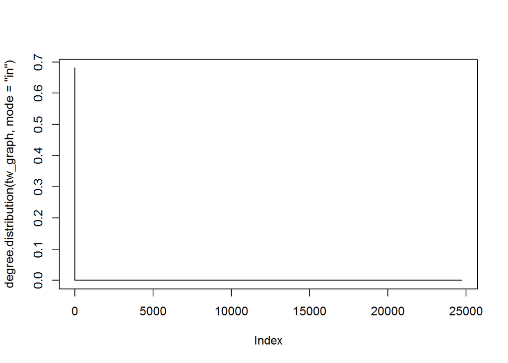

```r
plot(degree.distribution(tw_graph, mode = "in"), type = "l")
```

c) Visualize the network (try using ggplot2 or networkD3 libraries).

```r
simpleNetwork(network_tw, zoom =T)
```

- due to the size of the network i have attached a separate file for the network visualization

# Question 3. Developing a Language Model (for n-gram word sequences) (10 points).

1. Download Tweets from each user above that mention the hashtag you selected (over an appropriate time period).

```r
From <- "from:"
sxsw <- "+#SXSW2016"

tweets_list <- data.frame(stringsAsFactors=FALSE)

for(j in 1:100)
{

    tweets_object<-do.call("rbind",lapply(searchTwitter(paste(From,unique_usernames[j],sxsw,sep = ""),lang= "en"), as.data.frame))
    if(length(tweets_object)>0){
    tweets_list <- merge(tweets_list, tweets_object,  all=T)
    }
}
```

```r
# store only the  text from the tweet in a separate object

tweets_total<- tweets_list$text
```

2. For n = 1, n = 2 and n = 3, submit the list of the 10 most frequent sequences.

```r
# first we  process the ngrams for n=1, n=2 & n=3 using package tm
# here we create a corpus for analysis, in order to create a corpus we need to set up the source
tweets_source <- VectorSource(tweets_total)
corpus <- Corpus(tweets_source)
#After we have the corpus we do basic text processing to remove certain terms for better analysis
corpus <- tm_map(corpus, removePunctuation)
corpus <- tm_map(corpus, stripWhitespace)
corpus <- tm_map(corpus, removeWords, stopwords("english"))

ngram1 <- DocumentTermMatrix(corpus)
ngram1_2 <- as.matrix(ngram1)

frequency_ngram1 <- colSums(ngram1_2)
frequency_ngram1 <- sort(frequency_ngram1, decreasing=TRUE)
#for n= 2 ngram we use function bigram tokenizer to split words as a bigram
BigramTokenizer <-
  function(x)
    unlist(lapply(ngrams(words(x), 2), paste, collapse = " "), use.names = FALSE)

ngram2 <- TermDocumentMatrix(corpus, control = list(tokenize = BigramTokenizer))
ngram2_2 <- as.matrix(ngram2)

frequency_ngram2 <- rowSums(ngram2_2)
frequency_ngram2 <- sort(frequency_ngram2, decreasing=TRUE)

#for n=3 ngram we use a funtion trigram tokenizer to split the words as a trigram

trigramTokenizer <-
  function(x)
    unlist(lapply(ngrams(words(x), 3), paste, collapse = " "), use.names = FALSE)

ngram3 <- TermDocumentMatrix(corpus, control = list(tokenize = trigramTokenizer))
ngram3_1 <- as.matrix(ngram3)

frequency_ngram3 <- rowSums(ngram3_1)
frequency_ngram3 <- sort(frequency_ngram3, decreasing=TRUE)


# now we submit the top 10 sequences for each n value
frequency_ngram1[1:10]
```

```
##      sxsw2016          sxsw         video           see          hear
##           290            98            77            57            55
##           1kn      addicted leemajordamac    mediablitz nervedjsradio
##            54            54            54            54            54
```

```r
frequency_ngram2[1:10]
```

```
##          sxsw2016 video            addicted see        co nervedjsradio
##                      57                      54                      54
##      hear leemajordamac  leemajordamac addicted         mediablitz hear
##                      54                      54                      54
##       nervedjsradio 1kn            see sxsw2016           sxsw2016 sxsw
##                      54                      54                      29
## sxsw httpstcoygplgbkmrs
##                      27
```

```r
frequency_ngram3[1:10]
```

```
##                                   addicted see sxsw2016
##                                                      54
##                                    co nervedjsradio 1kn
##                                                      54
##                             hear leemajordamac addicted
##                                                      54
##                              leemajordamac addicted see
##                                                      54
##                           mediablitz hear leemajordamac
##                                                      54
##                                      see sxsw2016 video
##                                                      54
##                        sxsw2016 sxsw httpstcoygplgbkmrs
##                                                      27
##             batbar edu00a0u00bcedu00beu00a5 benfredette
##                                                      18
## benfredette edu00a0u00bdedu00b1u0089 httpstcokcfeni5vnm
##                                                      18
##                                   bhrama bull gryndfest
##                                                      18
```

3. For n = 1, n = 2 and n = 3, submit the sum of all frequencies of all sequences for that n.

```r
sum(frequency_ngram1)
```

```
## [1] 3399
```

```r
sum(frequency_ngram2)
```

```
## [1] 3450
```

```r
sum(frequency_ngram3)
```

```
## [1] 3152
```

4. Using these frequencies, generate a distance measure for individuals (e.g. they share the X most common frequency 3-gram terms, or 2-gram terms, or 1-gram term). How does this network look compared to the network generated in question 2?

```r
# here we consolidate the usernames and tweets from the users into a data frame

tweets_freq <- data.frame(screennames = tweets_list$screenName,tweets = tweets_list$text ,  stringsAsFactors = F)

tweets_freq <- aggregate(tweets~screennames, data = tweets_freq, concat, sep = " ")

tweets_freq$tweets <- iconv(tweets_freq$tweets, "UTF-8")


# Here the dataframe containing the network information and distnace measure between the users is created

ngramnetwork <- data.frame(src = character(), target = character(), distance = numeric(), stringsAsFactors = F)

#we intitialize the network data frame with the source and target information

for (i in 1:length(tweets_freq$screennames))
{
  k = i+1
  for (j in k:length(tweets_freq$screennames))
  {
    ngramnetworkdata <- data.frame(src=tweets_freq$screennames[i], target=tweets_freq$screennames[j], stringsAsFactors = F)
    ngramnetwork <- merge(ngramnetwork,ngramnetworkdata, all = T)

  }

}

# we calculate the distance measure between each user based on the string distance measured between all the tweets for the user with # SXSW with n= 3
for (k in 1:length(ngramnetwork$src))
{

  ngramnetwork$distance[k]<-stringdist(as.character(tweets_freq$tweets[tweets_freq$screennames == ngramnetwork$src[k]]),as.character(tweets_freq$tweets[tweets_freq$screennames == ngramnetwork$target[k]]), method = "qgram", q = 3)
}
# we remove rows where there is no common frequency terms
ngramnetwork <- na.omit(ngramnetwork)

#here we visualize th network
simpleNetwork(ngramnetwork, zoom = t)
```

[interactive chart not shown]

From the network we can see that network based on commonly used terms is highly interconnected and denser when compared to the network graph in question 2